# Introducción a la estadística

author: Alejandro Cáceres date:  
autosize: true

Escuela Técnica Superior de Ingeniería de Barcelona Este  
Universitat Politècnica de Catalunya (UPC)

Capítulo 3

# Objetivo

- Probabilidad condicional
- Independencia
- Teorema de Bayes

# Espacio muestral

**Definición:**

El conjunto de todos los valores posibles que pueden tomar las observaciones de un experimento aleatorio se llama espacio muestral del experimento. El espacio muestral se denota como S.

**Definición:**

Un evento es un subconjunto del espacio muestral de un experimento aleatorio.

# Operaciones de eventos

complemento: $E'$.

- $E1\cap E2$: $E1$ **Y** $E2$
- $E1\cup E2$: $E1$ **O** $E2$

# Probabilidad

**Interpretación frecuentista:**

la probabilidad $P(E)$ de un evento $E$ en el espacio muestral $S$ es una función tal

- $P(S)=1$
- $0 \leq P(E) \leq 1$
- cuando $E1\cap E2=\emptyset$
  $$P(E1\cup E2) =P(E1) + P(E2)$$

Interpretación frecuentista: $P(E)$ es la **frecuencia relativa** límite para el evento $E$ cuando el número de observaciones es infinito.

# Regla de suma

Cuando tenemos tres eventos A, B y C:

$P(A\cup B \cup C)=P(A) + P(B) + P(C)$  
$- P(A\cap B) - P(A\cap C) - P(B\cap C)$  
$+P(A\cap B \cap C)$

# Probabilidad conjunta

Probabilidad conjunta $P(A,B)=P(A\cap B)$

|  | B | B’ | suma |
| --- | --- | --- | --- |
| **A** | $P(A \cap B)$ | $P(A \cap B')$ | $P(A)$ |
| **A’** | $P(A' \cap B)$ | $P(A' \cap B')$ | $P(A')$ |
| **suma** | $P(B)$ | $P(B')$ | 1 |

# Probabilidad conjunta

Probabilidad conjunta $P(A,B,C)=P(A\cap B\cap C)$

$C$

|  | B | B’ | suma |
| --- | --- | --- | --- |
| **A** | $P(A \cap B\cap C)$ | $P(A \cap B'\cap C)$ | $P(A\cap C)$ |
| **A’** | $P(A' \cap B\cap C)$ | $P(A' \cap B'\cap C)$ | $P(A'\cap C)$ |
| **sum** | $P(B\cap C)$ | $P(B'\cap C)$ | $P(C)$ |

$C'$

|  | B | B’ | suma |
| --- | --- | --- | --- |
| **A** | $P(A \cap B \cap C')$ | $P(A \cap B'\cap C')$ | $P(A\cap C')$ |
| **A’** | $P(A' \cap B\cap C')$ | $P(A' \cap B'\cap C')$ | $P(A'\cap C')$ |
| **sum** | $P(B\cap C')$ | $P(B'\cap C')$ | $P(C')$ |

# Ejercicio

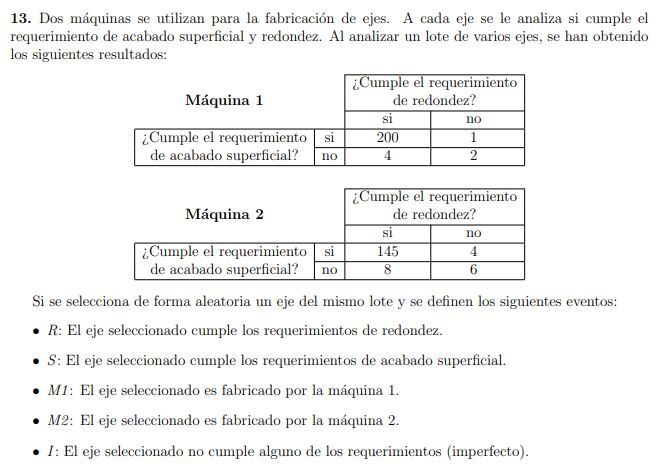

1. ¿Cuál es la probabilidad de que el eje cumpla los requerimientos de pulido superficial o los requerimientos de redondez o que sea fabricada por la máquina 1?

# Probabilidad conjunta

Consideremos diagnosticar la infección con una nueva prueba.

Estado de infección:

- sí (infectado)
- no (no infectado)

Prueba:

- positivo
- negativo

# Frecuencia relativa conjunta

|  | Infectado: si | Infectado: no | sum |
| --- | --- | --- | --- |
| **Prueba: positiva** | $n_{pos,si}$ | $n_{pos,no}$ | $n_{pos}$ |
| **Prueba: negativa** | $n_{neg,si}$ | $n_{neg,no}$ | $n_{neg}$ |
| **sum** | $n_{si}$ | $n_{no}$ | $n$ |

|  | - Infectado: sí - | - Infectados: no - | - suma - |
| --- | --- | --- | --- |
| - **Prueba: positiva** - | $fr(positivo, sí)$ | $fr(positivo, no)$ | $fr(positivo)$ |
| - **Prueba: negativa** - | $fr(negativo, sí)$ | $fr(negativo, no)$ | $fr(negativo)$ |
| - **suma** - | $fr(sí)$ | $fr(no)$ | $1$ |

Frecuencia de observar $positivo$ **Y** $no$:

- $fr(positivo,no)$= $fr(positivo \cap no)$= $\frac{n_{positivo,no}}{n}$

# Frecuencia codicional

Pensemos primero en términos de aquellos que están **infectados**

Entre los que están infectados (**sí**), ¿cuál es la frecuencia relativa de los individuos testados que dieron positivo?

- **Sensibilidad** (tasa de verdaderos positivos)

$$fr(positivo | sí) =\frac{n_{positivo, sí}}{n_ {sí}}$$

Escribimos la barra para indicar que la frecuencia se toma en el subgrupo de los están infectados

# Frecuencia codicional

Pensemos primero en términos de aquellos que **no** están **infectados**

Entre los **no** que están infectados (**no**), ¿cuál es la frecuencia relativa de los individuos testados que dieron negativo?

- **Especificidad** (tasa de verdaderos positivos)

$$fr(negativo | no) =\frac{n_{negativo, no}}{n_ {no}}$$

# Matriz de frecuencia condicional

|  | -Infección: Sí - | - Infección: No - |
| --- | --- | --- |
| - **Prueba: positiva** - | fr (positivo \| sí) | fr (positivo \| no) |
| - **Prueba: negativa** - | fr (negativo \| sí) | fr (negativo \| no) |
| - **suma** - | 1 | 1 |

# Matriz de frecuencia condicional

Supongamos que las frecuencias son de $n$ suficientemente grandes para **estimar** las probabilidades

|  | -Infección: Sí - | - Infección: No - |
| --- | --- | --- |
| - **Prueba: positiva** - | 18/48 =0,375 | 12/312 =0,038 |
| - **Prueba: negativa** - | 30/48 =0,625 | 300/312 =0,962 |
| - **suma** - | 1 | 1 |

Nuestra herramienta de diagnóstico tiene baja sensibilidad (0.375) pero alta especificidad (0,962).

# La probabilidad condicional

Lo escribimos en términos de frecuencias.

$$fr(positivo | sí) =\frac{n_{positivo, sí}} {n_{sí}} =\frac {\frac {n_{positivo, sí}} {n}} {\frac {n_{sí }} {n}} =\frac {fr(positivo, sí)} {fr (sí)}$$

Por lo tanto, en el límite, esperamos tener una probabilidad del tipo

$$P(positivo | sí) =\frac{P (positivo \cap sí)} {P(sí)}$$

A eso lo llamaremos probabilidad condicional de un valor **positivo** en la prueba dado un valor de **sí** en la infección.

# La probabilidad condicional

**Definición:**

La probabilidad condicional de un evento $B$ dado un evento $A$, denotado como $P (A | B)$, es
$$P (A | B) =\frac {P (A \cap B)} {P (B)}$$

- puedes probar que la probabilidad condicional satisface los axiomas de probabilidad.
- es la probabilidad con el espacio muestral dado por $B$: $S_B$.

# Matriz de probabilidad condicional

Matriz **condicional** sobre el valor del estado de infección.

|  | -Infección: Sí - | - Infección: No - |
| --- | --- | --- |
| - **Prueba: positiva** - | P (positivo \| sí) | P (positivo \| no) |
| - **Prueba: negativa** - | P (negativo \| sí) | P (negativo \| no) |
| - **suma** - | 1 | 1 |

- Tasa de falsos positivos: la probabilidad de dar positivo **si** no se tiene la enfermedad $P (positivo | no)$
- Tasa de falsos negativos: la probabilidad de que la prueba sea negativa **si** se tiene la enfermedad $P (negativo | sí)$

# La otra matriz de probabilidad condicional

Volvamos a nuestro diagnóstico de infecciones.

Dentro de aquellos cuya prueba es positiva, ¿cuál es la probabilidad de tener la infección (sí)?

- **Valor predictivo positivo**

$$P(si|positivo)=\frac{P(si \cap positivo)}{P(positivo)}$$

# La otra matriz de probabilidad condicional

De la misma forma podemos preguntar:

Dentro de aquellos cuya prueba es negativa, ¿cuál es la probabilidad de no tener la enfermedad (no)?

- **Valor predictivo negativo**

$$P(no|negativo)=\frac{P(no \cap negativo)}{P(negativo)}$$

# La otra matriz de probabilidad condicional

Matriz **condicional** sobre el valor del resultado de la prueba.

|  | Infección: Sí | Infección: No | suma |
| --- | --- | --- | --- |
| **Prueba: positiva** | PPV: P (sí \| positivo) | P (no \| positivo) | 1 |
| **Prueba: negativa** | P (sí \| negativo) | VPN: P (no \| negativo) | 1 |

PPV: valor predicho positivo VPN: valor predicho negativo

¡Estos son realmente los valores que queremos saber cuando hacemos un test!

# La otra matriz de probabilidad condicional

Supongamos que las frecuencias son de $n$ suficientemente grandes para **estimar** las probabilidades

[output not shown]

# La probabilidad condicional

La probabilidad condicional se define como:
$$P(A|B) =\frac{P(A\cap B)}{P(B)}$$

- Las pruebas de diagnóstico son una aplicación importante de las probabilidades condicionales
- Ahora aprenderemos a responder otras preguntas usando la **Regla de multiplicación** y la **Regla de probabilidad total**

# Regla de multiplicación

Para dos eventos $A$ y $B$ tenemos la regla de multiplicación

$$P(A \cap B) = P(A|B) P(B)$$

que se desprende de la definición de probabilidad condicional

# Joint probability matrix

La matrix de probabilidad conjunta se puede escribir en términos de las probabilidades condicionales

|  | Infección: Yes | Infección: No | **suma** |
| --- | --- | --- | --- |
| **Prueba: positiva** | P(positivo \| si)P(si) | P(positivo \| no)P(no) | P(positivo) |
| **Prueba: negativa** | P(negativo \| yes)P(si) | P(negativo \| no) P(no) | P(negativo) |
| **sum** | P(si) | P(no) | 1 |

Probabilidad de ser $positivo$ y estar infectado $si$:

- $P(positivo \cap si) = P(positivo|si) P(si)$

# Regla de multiplicación

Los discos duros tienen tipos de errores:

- **Tiempo de espera** en ejecutar un comando: cuando un programa se cuelga / congela el acceso al disco (estadísticas SMART 188).
- Error **incorregible** sin conexión: al escribir hay un error con pérdida de información (estadísticas SMART 198).

# Regla de multiplicación

- La probabilidad de que un disco duro muestre un error de **tiempo de espera** es de 0.02.
- **Cuando** hay un error de **tiempo de espera**, la probabilidad de un error **incorregible** es 0.0077.

Estos son los datos reales obtenidos de [data.world](https://data.world/scuttlemonkey/hard-drive-reliability-sample)

- ¿Cuál es la probabilidad de observar errores en tiempo de espera **Y** errores incorregibles?

# Regla de multiplicación

¿Cuáles son las expresiones matemáticas de las siguientes dos oraciones?

- La probabilidad de que un disco duro muestre un error de **tiempo de espera** es de 0.02.
- **Cuando** hay un error de **tiempo de espera**, la probabilidad de un error **incorregible** es 0.0077.
- La probabilidad de un tiempo de espera **Y** errores incorregibles

# Regla de multiplicación

¿Cuáles son las expresiones matemáticas de las siguientes dos oraciones?

- La probabilidad de que un disco duro muestre un error de **tiempo de espera** es de 0.02: $P(T)=0.02$
- **Cuando** hay un error de **tiempo de espera**, la probabilidad de un error **incorregible** es 0.0077: $P(U|T)=0.0077$
- La probabilidad de un tiempo de espera **Y** errores incorregibles: $P(U\cap T)=?$

# Regla de multiplicación

De la definición de probabilidad condicional

$$P(U|T) = \frac{P(U \cap T)}{P(T)}$$
La **regla de multiplicación** es

$$P(U \cap T) = P(U|T) P(T)$$
Tenemos tenemos

$$P(U \cap T) = P(U|T) P(T)=0.0077 \times 0.02 =0.00015$$

# Regla de probabilidad total

Vamos a pensar en una situación en la que observamos los valores de un evento en todas las **condiciones** posibles y luego preguntamos:

¿Cuál es la probabilidad del evento? (probabilidad marginal)

# Joint Probability

Recuerda:

Cuando tenemos dos conjuntos con eventos mutuamente excluyentes podemos hacer la tabla de contingencia para las probabilidades conjuntas

|  | $R_1$ | $\bar{R_1}$ | **suma** |
| --- | --- | --- | --- |
| $R_2$ | $P(R_1 \cap R_2 )$ | $P(\bar{R_1} \cap R_2 )$ | $P(R_2)$ |
| $\bar{R_2}$ | $P(R_1 \cap \bar{R_2} )$ | $P(\bar{R_1} \cap \bar{R_2} )$ | $P(\bar{R_2})$ |
| **suma** | $P(R_1)$ | $P(\bar{R_1})$ | 1 |

Probabilidad marginal : $P(R_1)= P(R_1 \cap R_2) + P(R_1 \cap \bar{R_2})$

Para una colección de eventos mutuamente excluyentes $E1$… $En$ la probabilidad **marginal probability** de $A$

$$P(A) = P(A \cap E1)+P(A \cap E2)...+P(A \cap En)$$

# Regla de probabilidad total

**Regla de probabilidad total**

Escribimos la definición de la probabilidad marginal $P(A)= P(A \cap B)+P(A \cap B')$ en tétminos de las probabilidades condicionales:

$$P(A)= P(A|B')P(B') + P(A|B)P(B)$$

cuando $B$ y $B'$ son mutuamente excluyentes ($B \cap B' =\emptyset$).

# Regla de probabilidad total

Probabilidad conjunta $P(A,B)=P(A\cap B)$

|  | E1 | E2 | … | En | suma |
| --- | --- | --- | --- | --- | --- |
| **A** | $P(A \cap E1)$ | $P(A \cap E3)$ | … | $P(A \cap En)$ | $P(A)$ |
| **A’** | $P(A' \cap E1)$ | $P(A' \cap E2)$ | … | $P(A \cap En)$ | $P(A')$ |

Para una collección de eventos mutuamente excluyentes $\{E1, E2, ... En \}$, la **regla de probabilidad total** es

$$P(A)= P(A|E1)P(E1) + P(A|E2)P(E2) + ... +P(A|En)P(En)$$

# Regla de probabilidad total

¿Cuál es la probabilidad de cáncer $P (C)$ cuando conocemos sus probabilidades condicionales para hombres y mujeres?

El cáncer depende en gran medida del sexo

Probabilidad de cáncer para las mujeres: $P (C | W) =0.05$  
Probabilidad de cáncer para hombres: $P (C | W ') =0.07$  
Probabilidad de ser mujer: $P (W) =0.5$  
Probabilidad de ser hombre: $P (W ') =0.5$

# Regla de probabilidad total

- individuos con cáncer =hombres con cáncer $\cup$ mujeres con cáncer
- $C =(C \cap W ') \cup (C \cap W)$

$(C \cap W ')$ y $(C \cap W)$ son mutuamente excluyentes entonces

$$P (C) =P (C \cap W ') + P (C \cap W)$$

# Regla de probabilidad total

$P (C) =P (C \cap W ') + P (C \cap W)$  
$=P (C | W ') P (W') + P (C | W) P (W)$

La probabilidad de tener cáncer es - la probabilidad de tener cáncer al ser hombre multiplicada por la probabilidad de ser hombre

**más**

- la probabilidad de tener cáncer al ser mujer multiplicada por la probabilidad de ser mujer

# Regla de probabilidad total

$P(C)= P(C|W')P(W') + P(C|W)P(W)$  
$= 0.07\times 0.5 + 0.05\times 0.5$  
$= 0.06$

Está claramente entre las probabilidades condicionales (0.07, 0.05)

# Independencia estadística

En muchas aplicaciones, queremos saber si el conocimiento de un evento condiciona el resultado de otro evento.

- hay casos en los que queremos saber si los eventos no están condicionados

# Independencia estadística

Considere los conductores para los que medimos si tienen fracturas y si su capacidad de conducción es defectuosa.

|  | Fracturas: sí | Fracturas: no | suma |
| --- | --- | --- | --- |
| **Defectuoso: sí** | 2 | 18 | 20 |
| **Defectuoso: no** | 38 | 342 | 380 |
| **suma** | 40 | 360 | 400 |

¿La probabilidad de tener fracturas aumenta la probabilidad de tener una conducción defectuasa?

# Independencia estadística

Calculamos las frecuencias conjuntas relativas y supongamos que estiman correctamente las probabilidades conjuntas cuando $n =400$

|  | Fracturas (F) | no Fracturas (F’) | suma |
| --- | --- | --- | --- |
| **Defectuoso (D)** | $P(D \cap F)=0.005$ | $P(D \cap F')=0.045$ | $P(D)=0.05$ |
| **no Defectuoso (D’)** | $P(D' \cap F)=0.095$ | $P(D' \cap F')=0.855$ | $P(D')= 0.95$ |
| **sum** | $P(F)=0.1$ | $P(F')=0.9$ | 1 |

Las marginales son

- $P(D)=P(D \cap F) + P(D \cap F')=0.05$
- $P(D')=P(D' \cap F) + P(D' \cap F')= 0.95$.

# Independencia estadística

¿Cuál es la probabilidad condicional de observar un conductor defectuoso **si** tiene fracturas?

|  | F | F’ |
| --- | --- | --- |
| **D** | P(D\|F)=$P(D\cap F)/P(F)$ = 0.05 | P(D\|F’)=$P(D\cap F')/P(F')$=0.05 |
| **D’** | P(D’\|F)=$P(D'\cap F)/P(F)$=0.95 | P(D’\|F’)=$P(D'\cap F')/P(F')$=0.95 |
| **sum** | 1 | 1 |

¡Los marginales y las probabilidades condicionales son iguales!

- $P(D|F)=P(D|F')=P(D)$
- $P(D'|F)=P(D'|F')=P(D')$

Las fracturas no condicionan la conductividad del material.

# Independencia estadística

La probabilidad de que un conductor tenga una conducción defectuosa **no** depende de la probabilidad de que presente una fractura.

$$P (D) =P (D | F)$$

# Independencia estadística

Dos eventos $A$ y $B$ son estadísticamente independientes si

- $P (A | B) =P (A)$; $A$ es independiente de $B$
- $P (B | A) =P (B)$; $B$ es independiente de $A$

y por la regla de la multiplicación, su probabilidad conjunta es

- $P(A\cap B)=P(A|B)P(B)=P(A)P(B)$

la multiplicación de sus probabilidades marginales.

# Independencia estadística

|  | F | F’ | sum |
| --- | --- | --- | --- |
| **D** | $P(D \cap F)=0.005$ | $P(D \cap F')=0.045$ | $P(D)=0.05$ |
| **D’** | $P(D' \cap F)=0.095$ | $P(D' \cap F')=0.855$ | $P(D')= 0.95$ |
| **sum** | $P(F)=0.1$ | $P(F')=0.9$ | 1 |

Confirma que todas los elementos de la matriz de probabilidad conjunta son el producto de las probababilidades marginales.

Por ejemplo:

- $P(F)P(D)= P(D \cap F)$
- $P(D')P(F')=P(D' \cap F')$

# Independencia estadística

Dos monedas: $S=\{(H,H), (H,T), (T,H), (T,T)\}$

Cara: $H$ y Cruz: $T$

|  | H | T | sum |
| --- | --- | --- | --- |
| **H** | $P(H \cap H)=1/4$ | $P(H \cap T)=1/4$ | $P(H)=1/2$ |
| **T** | $P(T \cap H)=1/4$ | $P(T \cap T)=1/4$ | $P(T)= 1/2$ |
| **sum** | $P(H)=1/2$ | $P(T)=1/2$ | 1 |

- Obtener cara en la primera moneda no condiciona obtener cruz en el resultado de la segunda moneda $P (T | H) =P (T) =1/2$
- la probabilidad de obtener una cara y luego una cruz es el producto de cada resultado independiente $P (H, T) =P (H) * P (T) =1/4$

# Ejercicio

En una avenida hay un sistema de 3 semáforos sucesivos. La probabilidad de encontrar el primer semáforo en rojo es 0.6. En los siguientes semáforos, tenemos las probabilidades $P(R_{j+1}|R_j) = 0.15$ y $P(R_{j+1}|R_j) = 0.25$, para $j = 1,2$, donde $R_j$ representa el suceso [encontramos en rojo el semáforo j-ésimo]. Aceptando que la probabilidad de encontrar en rojo un semáforo depende únicamente del estado del semáforo anterior, calcula la probabilidad de que, al circular por el sistema de tres semáforos, ocurran los siguientes sucesos:

1. Encontramos todos los semáforos en rojo.
2. Encontramos algún semáforo en rojo.
3. Encontramos, exactamente, un semáforo en rojo

Nota: Considera los elementod de la matrix de probabilidad conjunta y el hecho de que:

$$P(R_1 \cap R_2 \cap R_3 ) = P(R_3|R_2,R1)P(R_2|R_1)P(R_1)=P(R_3|R_2)P(R_2|R_1)P(R_1)$$

ya que $P(R_3|R_2,R_1)=P(R_3|R_2)$, porque $R_3$ es independente de $R_1$

# Teorema de Bayes

Recordemos nuestro ejemplo de diagnóstico.

Cada individuo es un experimento aleatorio con dos medidas: (Infección, Prueba)

|  | Infección: sí | Infección: no | suma |
| --- | --- | --- | --- |
| **Prueba: positiva** | $P (pos, sí)$ | $P (pos, no)$ | $P (pos)$ |
| **Prueba: negativa** | $P (neg, sí)$ | $P (neg, no)$ | $P (neg)$ |
| **suma** | $P (sí)$ | $P (no)$ | $1$ |

Asumimos **sabíamos** todas las entradas en la **matriz de probabilidad conjunta**.

# Teorema de Bayes

calculamos la **matriz condicional** en el estado de infección

|  | Infección: Sí | Infección: No |
| --- | --- | --- |
| **Prueba: positiva** | P (positivo \| sí) | P (positivo \| no) |
| **Prueba: negativa** | P (negativo \| sí) | P (negativo \| no) |
| **suma** | 1 | 1 |

- Sensibilidad: La probabilidad de dar positivo **si** tener la enfermedad $P (positivo | sí)$
- Especificidad: Probabilidad de dar negativo **si** no tener la enfermedad $P (negativo | no)$

# Teorema de Bayes

y también calculamos la otra **matriz condicional** en el resultado de la prueba

|  | Infección: Sí | Infección: No | sum |
| --- | --- | --- | --- |
| **Prueba: positiva** | P (sí \| positivo) | P (no \| positivo) | 1 |
| **Prueba: negativa** | P (sí \| negativo) | P (no \| negativo) | 1 |

- Valor predictivo positivo: la probabilidad de tener la enfermedad **si** da positivo $P (sí | positivo)$
- Valor predictivo negativo: la probabilidad de no tener la enfermedad **si** prueba negativo $P (no | negativo)$

# Teorema de Bayes

Ahora imaginemos una situación real actual.

Con estos datos, ¿cuál es la probabilidad de que estar infectado **si** la prueba de PCR es positiva: $P (sí | positivo)$?

# Teorema de Bayes

Para estudiar el rendimiento de una nueva prueba de diagnóstico:

- selecciona muestras que son inadecuadas (enfermedad: **sí**) y aplica la prueba, tratando de encontrar su sensibilidad: $P (positivo | sí)$ (0,70 para PCR)
- selecciona las muestras que son adecuadas (enfermedad: **no**) y aplica la prueba, tratando de encontrar su especificidad: $P (negativo | no)$ (0,96 para PCR)

Pero cuando aplica la prueba en el mundo real, no sabe si su muestra es inadecuada: quiere saber cuál es la probabilidad de ser **inadecuada** *si* su prueba es **positiva**: $P (sí | positivo)$

# Teorema de Bayes

Supongamos que las frecuencias son de $n$ suficientemente grandes para **estimar** las probabilidades

[output not shown]

De esta matriz, ¿podemos obtener $P (sí | positivo)$?

# Teorema de Bayes

Pero no conocemos esta matriz

|  | Infección: Sí | Infección: No | sum |
| --- | --- | --- | --- |
| **Prueba: positiva** | P (sí \| positivo) | P (no \| positivo) | 1 |
| **Prueba: negativa** | P (sí \| negativo) | P (no \| negativo) | 1 |

¿Cómo pasar de una matriz a otra? ¿cómo revirtimos el condicionamiento?:

$P (positivo | sí) \rightarrow P (sí | positivo)$

# Teorema de Bayes

Queremos averiguar cuál es la probabilidad de estar infectado si la prueba es positiva $P (sí | positivo)$, cuando por experimentos en el laboratorio tenemos,

Aplicamos el teorema de Bayes. Derivémoslo …

# Teorema de Bayes

De la definición de probabilidad condicional

$$P (positivo | sí) =\frac {P (positivo \cap sí)} {P (sí)}$$

tenemos la **regla de multiplicación**

$$P(positive \cap yes)= P(positive|yes) \times P(yes)$$

donde escribimos la probabilidad **conjunta** de dos eventos en términos de probabilidad condicional y probabilidad marginal.

# Teorema de Bayes

Ten en cuenta que

$P (positivo \cap sí) =P (sí \cap positivo)$

aplicando la regla de la multiplicación en ambos lados tenemos

$P (positivo | sí) \times P (sí) =P (sí | positivo) \times P (positivo)$

y luego tenemos el teorema de Bayes:

$P (sí | positivo) = \frac {P (positivo | sí) \times P (sí)} {P (positivo)}$

# Teorema de Bayes

Teorema de Bayes:

$P (sí | positivo) =\frac {P (positivo | sí) \times P (sí)} {P (positivo)}$

Sabemos

- la sensibilidad $P (positivo | sí)$
- la prevalencia $P (sí)$

y necesitamos la probabilidad de dar positivo $P (positivo)$ en la población.

# Teorema de Bayes

Necesitamos la **regla de probabilidad total**, que es la siguiente

|  | Infección: sí | Infección: no | suma |
| --- | --- | --- | --- |
| **Prueba: positiva** | $P (pos \cap sí)$ | $P (pos \cap no)$ | $P (pos)$ |
| **Prueba: negativa** | $P (neg \cap sí)$ | $P (neg \cap no)$ | $P (neg)$ |
| **suma** | $P (sí)$ | $P (no)$ | $1$ |

la probabilidad marginal $P(positivo)$ se puede escribir en términos de las probabilidades condicionales de eventos de infección disjuntos.

$P (positivo) =P (positivo \cap sí) + P (positivo \cap no)$

$=P (positivo | sí) P (sí) + P (positivo | no) P (no)$

# Teorema de Bayes

Ahora el teorema de Bayes en términos de las probabilidades de los eventos de prueba es

$P(sí | positivo) =\frac {P (positivo | sí) \times P (sí)} {P (positivo | sí) P (sí) + P (positivo | no) P (no)}$

Por lo tanto: $P (sí | positivo) =0.47$

# Teorema de Bayes

**Teorema**

Si $E1, E2, ..., Ek$ son $k$ eventos mutuamente excluyentes y exhaustivos ($\cup_{i=1..k} E_k=S$) y $B$ es cualquier evento,

$$P (Ei | B) =\frac {P (B | Ei) P (Ei)} {P (B | E1) P (E1) + ... + P (B | Ek) P (Ek)}$$

# Teorema de Bayes

Apliquémoslo ahora a la probabilidad de no estar infectado si la prueba es negativa

$P (no | negativo) =\frac {P (negativo | no) P (no)} {P (negativo | no) P (no) + P (negativo | sí) P (sí)}$

La sustitución de todos los valores da

$P(no | negativo) =0.98$

Las pruebas son buenas para descartar infecciones y no tan buenas para confirmarlas.

# Ejercicio

En una determinada población, el $20\%$ de los individuos son hipertensos (H). Además, algunas de las personas saben (S) si son o no hipertensas, y otras no lo saben. La probabilidad que siendo hipertensos sepan si lo son o no es del $0.7$ y la probabilidad que no siendo hipertensos no sepan si lo son o no es de $0.6$. En esta población, si una persona no sabe si es o no hipertensa, ¿cuál es la probabilidad que lo sea?

# Ejercicio

# Ejercicio

si una persona no sabe si es o no hipertensa, ¿cuál es la probabilidad que lo sea?

$P(H|\bar{S})=\frac{P(\bar{S}|H)P(H)}{P(\bar{S})}$

$=\frac{P(\bar{S}|H)P(H)}{P(\bar{S}|H)P(H) +P(\bar{S}|\bar{H})P(\bar{H})}$

$=\frac{0.3\cdot 0.2}{0.3 \cdot 0.2 + 0.6\cdot 0.8}=0.111$

# Ejercicio

Para detectar la presencia de un cierto tipo de bacteria en el agua se realiza un test. Si el agua contiene bacterias, el test da positivo el 70% de veces. Si no hay bacterias, detecta da negativo un 60% de las veces. Además sabemos que la probabilidad de que una muestra tenga bacterias de este tipo es 0.2. Calcular la probabilidad de que haya bacterias, si el resulatdo de un test es positivo.

# Ejercicio

Escribamos lo que nos da el problema

- $P(P|C)=0.7$ por lo tanto $P(\bar{P}|C)=0.3$
- $P(\bar{P}|\bar{C})=0.6$ por lo tanto $P(P|\bar{C})=0.4$
- $P(C)= 0.2$ por lo tanto $P(\bar{C})= 0.8$

# Exercise

Calcular la probabilidad de que haya bacterias, si el resulatdo de un test es positivo: $P(C|P)$?

Bayes $P(C|P)=\frac{P(P|C)P(C)}{P(P|C)P(C)+P(P|\bar{C})P(\bar{C})}$

$P(C|P)=\frac{0.7\cdot 0.2}{0.7\cdot 0.2+0.4 \cdot 0.8}=0.3043$

# Resumen

- Probabilidad condicional: $P(A|B) =\frac{P(A\cap B)}{P(B)}$
- Regla de la multiplicación:

$P (A \cap B) =P (A | B) P (B)$

- Regla de la suma de probabilidad total

$P(A)= P(A|E1)P(E1) + P(A|E2)P(E2) + ... +P(A|En)P(En)$, when $\{E1, E2, ...En\}$ are mutually exclusive

# Resumen

- A y B son estadíticamente independientes cuando

$P(A|B)=P(A)$

$P(B|A)=P(B)$

$P(A\cap B)=P(A)P(B)$

- Teorema Bayes